# How to upgrade a STM32 project

8.1.0  
How to upgrade a STM32 project

- [ Index ]
- Overview
- Manual update

# How to upgrade a STM32 project

X-CUBE-AI Expansion Package

r1.1

AI PLATFORM r8.1.0 (Embedded Inference Client API 1.2.0)

Command Line Interface r1.7.0

## Overview

This article describes how to upgrade a STM32CubeMX-based or proprietary source tree with a new version of the X-CUBE-AI library. The update of generated c-model files is described in the [CLI], “Update an ioc-based project” section. For the interface between them, backward or/and forward compatibility is never considered, if the generated c-model files are updated with a new version of the X-CUBE-AI tools, the X-CUBE-AI library files should be also aligned. Without specific notification/advice, (see “API Breaking changes” article [BREAK]) at source level, no breaking change to the embedded inference API that can break the client’s application is expected.

Typical source tree (`%ROOT_PRJ_DIR%` indicates the root directory of the project):

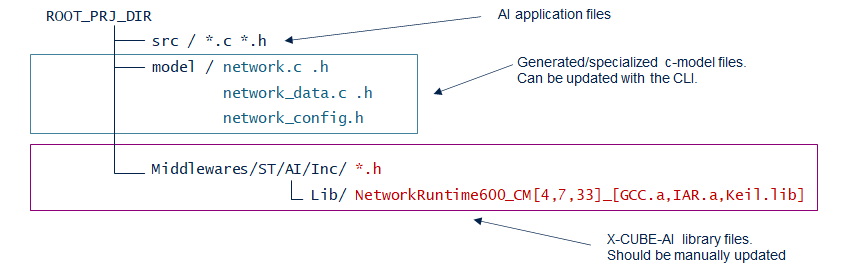

- If the project source tree has been generated through a STM32CubeMX-based project with the X-CUBE-AI expansion pack, the IOC-file can be re-load to update the project including a new version of the X-CUBE-AI pack.
- Command to update the c-model files with the CLI:

  ```powershell
  $ stm32ai generate <my_model> <my_options> -o %ROOT_PRJ_DIR%/model/
  ```

## Manual update

The C-header files and network runtime library can be directly copied from the X-CUBE-AI pack. `%X_CUBE_AI_DIR%` indicates the root location where the X-CUBE-AI pack is installed.

| directory | contains |
| --- | --- |
| `%X_CUBE_AI_DIR%/Middlewares/ST/AI/Inc` | all C-header files requested to build the generated c-model files |
| `%X_CUBE_AI_DIR%/Middlewares/ST/AI/Lib` | by STM32 series and by IDE, the network runtime libraries |

| tool-chain | contains |
| --- | --- |
| ABI2.1 | the library for the IAR Embedded Workbench® IDE - ARM v8.x tool-chain |
| GCC | the library for the GNU ARM Embedded-based project - STMicroelectronics - STM32CubeIDE version 1.0.1 or late |
| MDK | the library for the Keil® - MDK-ARM Professional Version - µVision® V5.25.2.0 tool-chain |

In each `<tool-chain>` directory, this is one sub-directory by STM32 series. According the targeted STM32 device, specialized STM32 series should be selected first else generic STM32 Cortex M should be used.

| STM32 | for which STM32 device |
| --- | --- |
| STM32WL | specialized library for the STM32WLxx devices |
| STM32MP1 | specialized library for the CortexM4 core inside a STM32MP1 device |
| STM32H7 | specialized library for the STM32H7xx devices |
| ARMCortexM4 | generic library for the STM32 devices based on the ARM Cortex M4, STM32F3xx, STM32L4xx, STM32F4xx |
| ARMCortexM7 | generic library for the STM32 devices based on the ARM Cortex M7, STM32F7xx |
| ARMCortexM33 | generic library for the STM32 devices based on the ARM Cortex M33, STM32L5xx, STM32U5xx |

**Warning** — When the project source tree is updated, **don’t forget** to update also the associated build system to use the new library file.

**Info** — Library files with the name suffixed with `_PIC` should be not used.

### Upgrading the X-CUBE-AI library for a STM32F411 device and GCC-base build system

```powershell
# remove the previous files
rm %ROOT_PRJ_DIR%/Middelwares/ST/AI/Inc/*.h
rm %ROOT_PRJ_DIR%/Middelwares/ST/AI/Lib/*.a
# copy the new files
cp %X_CUBE_AI_DIR%/Middlewares/ST/AI/Inc/*  %ROOT_PRJ_DIR%/Middelwares/ST/AI/Inc/
cp %X_CUBE_AI_DIR%/Middlewares/ST/AI/Lib/GCC/ARMCortexM4/NetworkRuntime700_CM4_GCC.a
     %ROOT_PRJ_DIR%/Middelwares/ST/AI/Lib/
```

### Upgrading the X-CUBE-AI library for a STM32H7xx device and Keil IDE

```powershell
# remove the previous files
rm %ROOT_PRJ_DIR%/Middelwares/ST/AI/Inc/*.h
rm %ROOT_PRJ_DIR%/Middelwares/ST/AI/Lib/*.a
# copy the new files
cp %X_CUBE_AI_DIR%/Middlewares/ST/AI/Inc/*  %ROOT_PRJ_DIR%/Middelwares/ST/AI/Inc/
cp %X_CUBE_AI_DIR%/Middlewares/ST/AI/Lib/MDK/STM32H7/NetworkRuntime700_CM7_Keil.lib
     %ROOT_PRJ_DIR%/Middelwares/ST/AI/Lib/
```

Embedded Documentation - **How to upgrade a STM32 project**  
X-CUBE-AI Expansion Package  
r1.1 - AI PLATFORM r8.1.0 (Embedded Inference Client API 1.2.0) - Command Line Interface r1.7.0

Information in this document is provided solely in connection with ST products. The contents of this document are subject to change without prior notice.  
© Copyright STMicroelectronics 2020. All rights reserved. www.st.com